# Normalization performance report

- study: Netherlands ALS ProjectMine
- author: Marta Nabais
- date: 08 October, 2019

## Parameters used to test normalization

```
## $variables
## [1] "Slide"       "sentrix_row" "sentrix_col" "Sex"         "cohort"
##
## $control.pcs
##  [1]  1  2  3  4  5  6  7  8  9 10
##
## $batch.pcs
##  [1]  1  2  3  4  5  6  7  8  9 10
##
## $batch.threshold
## [1] 0.01
##
## $colours
## NULL
```

## Control probe scree plots

The variance captured by each principal component.

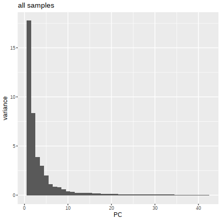

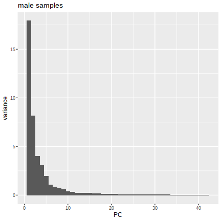

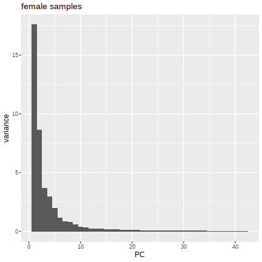

## Principal components of the control probes

The following plots show the first 3 principal components of the control matrix colored by batch variables. Batch variables with more than 10 levels are omitted.

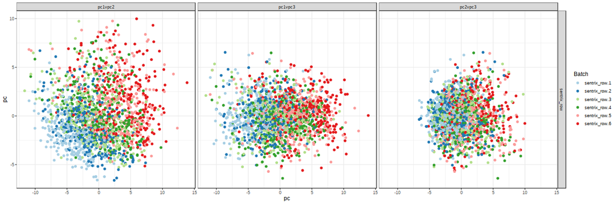

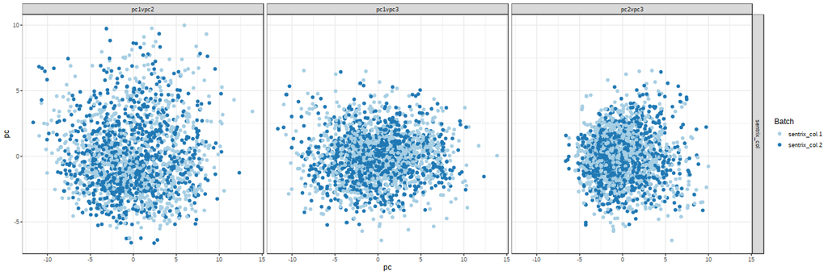

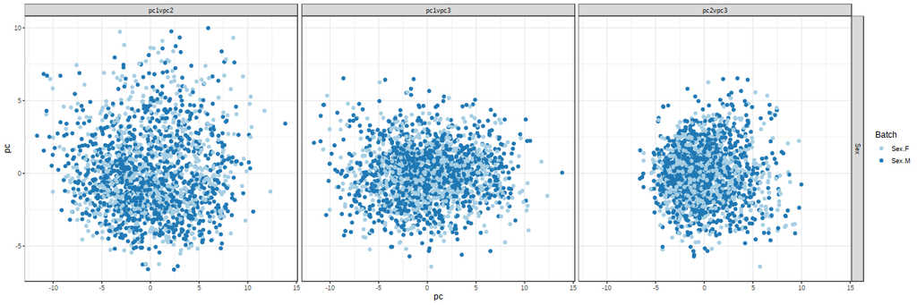

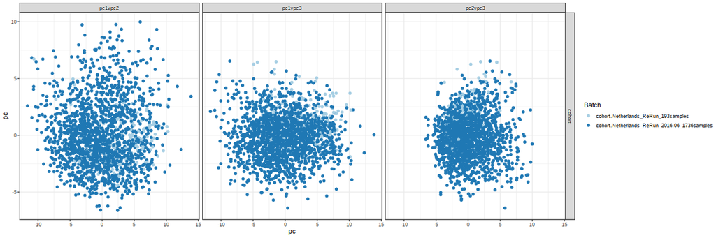

## Control probe associations with measured batch variables

Principal components of the control probes were regressed against batch variables. Shown are the \(-log_{10}\) p-values for these regressions. The horizontal dotted line denotes \(p = 0.05\) in log-scale.

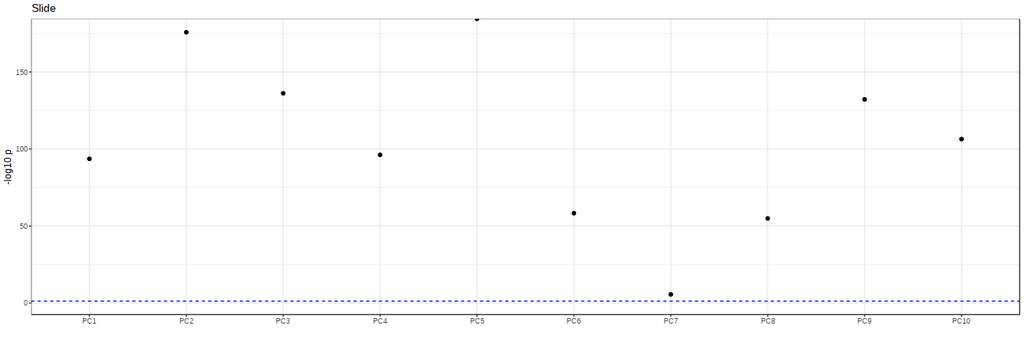

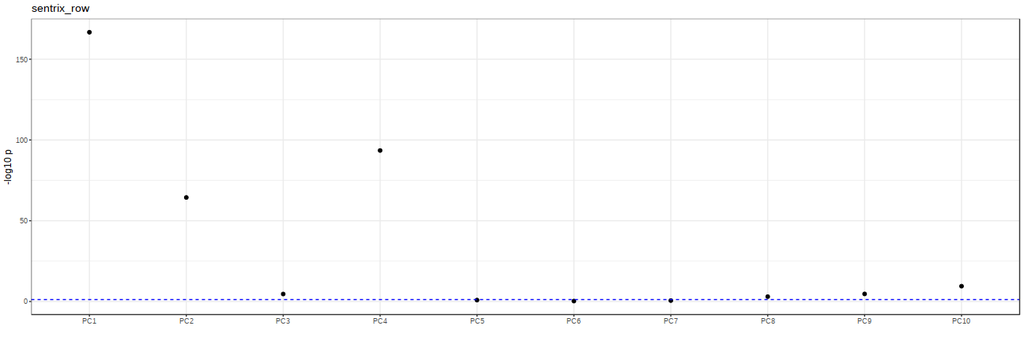

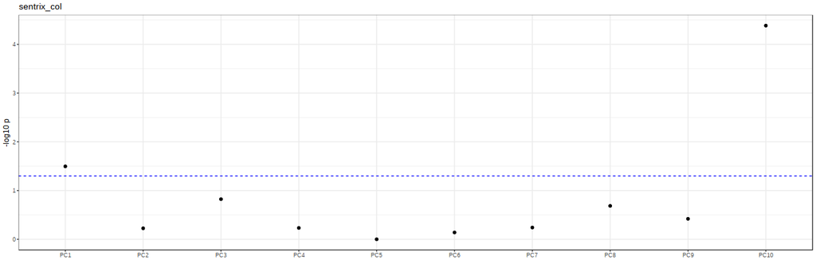

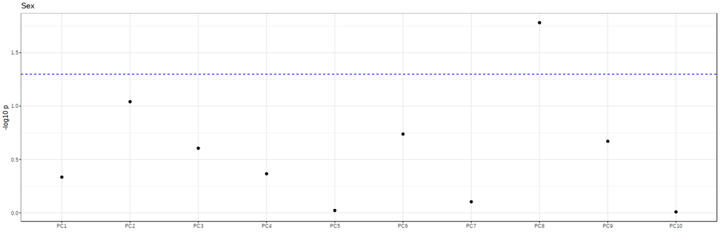

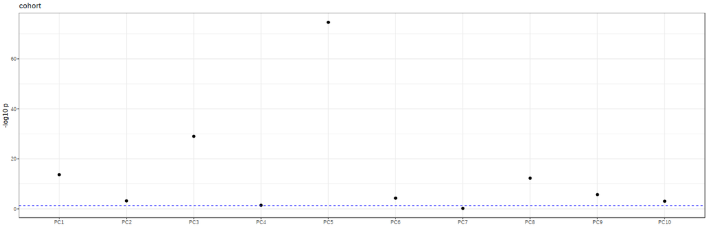

The following plots show regression coefficients when each principal component is regressed against each batch variable level along with 95% confidence intervals. Cases significantly different from zero are coloured red (p < 0.01, t-test).

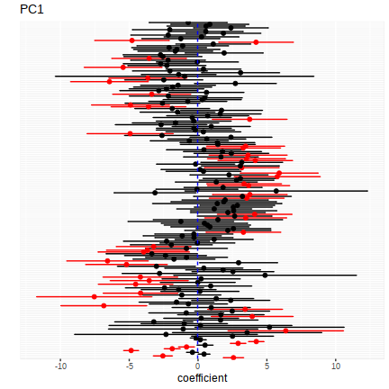

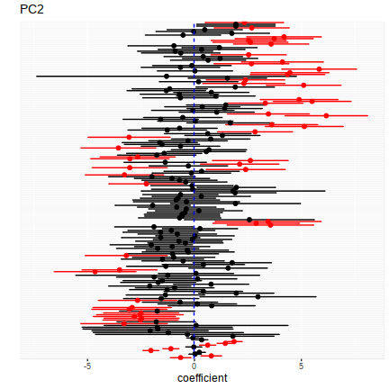

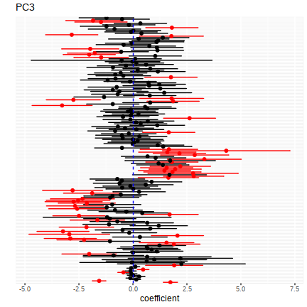

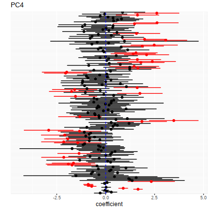

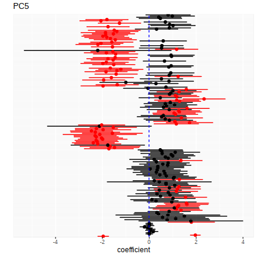

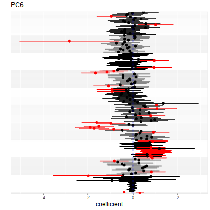

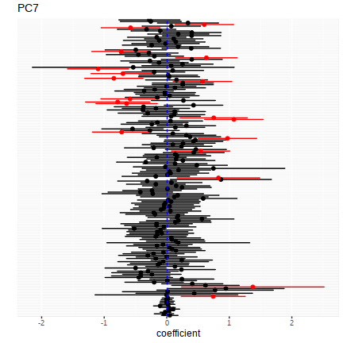

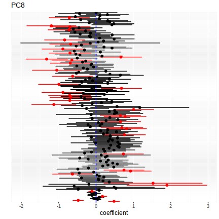

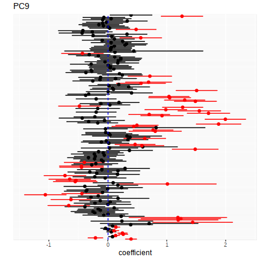

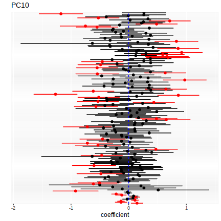

| batch.variable | batch.value | principal.component | test | p.value | estimate | lower | upper |
| --- | --- | --- | --- | --- | --- | --- | --- |
| Slide |  | PC1 | F-test | 2.33e-94 | 6.234 |  |  |
| Slide | 200053730134 | PC1 | t-test | 6.77e-04 | 6.372 | 2.1837 | 10.5610 |
| Slide | 200109350044 | PC1 | t-test | 3.04e-03 | 3.936 | 0.9677 | 6.9034 |
| Slide | 200109350086 | PC1 | t-test | 4.82e-03 | 3.419 | 0.7082 | 6.1308 |
| Slide | 200109360022 | PC1 | t-test | 9.43e-07 | -6.848 | -9.9622 | -3.7330 |
| Slide | 200123480008 | PC1 | t-test | 5.70e-05 | -7.541 | -11.7247 | -3.3580 |
| Slide | 200123480025 | PC1 | t-test | 5.68e-04 | -4.179 | -6.8870 | -1.4703 |
| Slide | 200123480069 | PC1 | t-test | 1.84e-04 | -4.534 | -7.2407 | -1.8271 |
| Slide | 200123480081 | PC1 | t-test | 5.12e-03 | -3.546 | -6.3777 | -0.7153 |
| Slide | 200123480090 | PC1 | t-test | 5.48e-04 | -4.191 | -6.8989 | -1.4823 |
| Slide | 200123530083 | PC1 | t-test | 8.88e-05 | -5.200 | -8.1630 | -2.2379 |
| Slide | 200123530105 | PC1 | t-test | 6.91e-07 | -6.578 | -9.5330 | -3.6230 |
| Slide | 200123530129 | PC1 | t-test | 7.85e-03 | -3.946 | -7.2640 | -0.6279 |
| Slide | 200123530133 | PC1 | t-test | 5.62e-03 | -3.678 | -6.6465 | -0.7090 |
| Slide | 200123530145 | PC1 | t-test | 7.83e-03 | -3.227 | -5.9385 | -0.5147 |
| Slide | 200347970053 | PC1 | t-test | 6.63e-03 | 3.294 | 0.5823 | 6.0057 |
| Slide | 200362700055 | PC1 | t-test | 9.14e-03 | 3.463 | 0.4933 | 6.4323 |
| Slide | 200362700082 | PC1 | t-test | 6.90e-04 | 4.115 | 1.4063 | 6.8235 |
| Slide | 200362700169 | PC1 | t-test | 3.57e-03 | 3.535 | 0.8237 | 6.2455 |
| Slide | 200362700187 | PC1 | t-test | 1.93e-03 | 3.762 | 1.0517 | 6.4718 |
| Slide | 200394870015 | PC1 | t-test | 5.81e-03 | 3.673 | 0.6965 | 6.6502 |
| Slide | 200394870018 | PC1 | t-test | 5.82e-03 | 3.346 | 0.6344 | 6.0575 |
| Slide | 200394870055 | PC1 | t-test | 3.88e-05 | 5.752 | 2.6314 | 8.8727 |
| Slide | 200394870060 | PC1 | t-test | 3.26e-06 | 5.896 | 3.0697 | 8.7225 |
| Slide | 200394870091 | PC1 | t-test | 8.84e-03 | 3.176 | 0.4644 | 5.8886 |
| Slide | 200394970002 | PC1 | t-test | 6.09e-04 | 4.156 | 1.4476 | 6.8645 |
| Slide | 200394970006 | PC1 | t-test | 5.47e-03 | 3.519 | 0.6880 | 6.3505 |
| Slide | 200394970014 | PC1 | t-test | 4.09e-03 | 3.636 | 0.8055 | 6.4673 |
| Slide | 200394970044 | PC1 | t-test | 6.96e-03 | 3.274 | 0.5626 | 5.9861 |
| Slide | 200394970048 | PC1 | t-test | 6.36e-03 | 3.457 | 0.6253 | 6.2883 |

[output cut: 478 more lines]

## Principal components of the normalized betas

The following plots show the first 3 principal components of the most variable probes colored by batch variables. Batch variables with more than 10 levels are omitted.

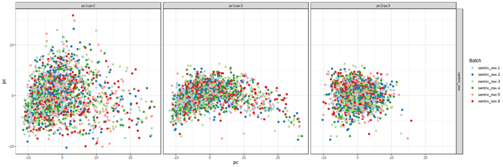

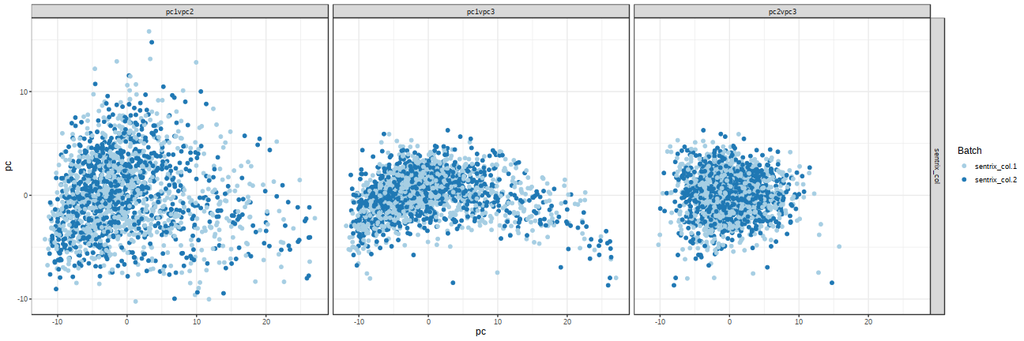

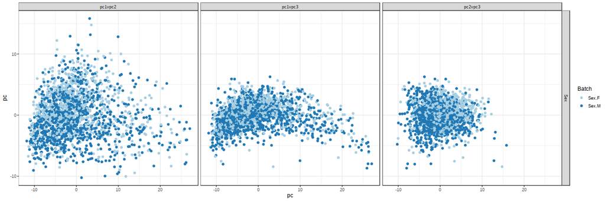

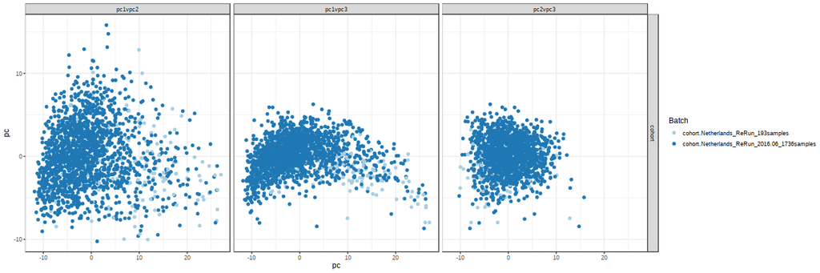